# BASIC ANOVA TEST

DORIS BENIG

2025-01-25

Does the type of treatment significantly affect the weight of plants?

Hypothesis:

Null Hypothesis $H_0$: The type of treatment does not have a significant effect on the weight of plants. Alternative Hypothesis $H_1$: The type of treatment has a significant effect on the weight of plants.

# Step 1: Load the necessary libraries

```r
# Data Wrangling libraries

library(tidyverse)
library(dplyr)
```

# Step 2: Load and explore the datasete

```r
# Load the dataset
PlantGrowth
```

```
##    weight group
## 1    4.17  ctrl
## 2    5.58  ctrl
## 3    5.18  ctrl
## 4    6.11  ctrl
## 5    4.50  ctrl
## 6    4.61  ctrl
## 7    5.17  ctrl
## 8    4.53  ctrl
## 9    5.33  ctrl
## 10   5.14  ctrl
## 11   4.81  trt1
## 12   4.17  trt1
## 13   4.41  trt1
## 14   3.59  trt1
```

[output cut: 16 more lines]

```r
str(PlantGrowth) #This is an R inbuilt dataset
```

```
## 'data.frame':    30 obs. of  2 variables:
##  $ weight: num  4.17 5.58 5.18 6.11 4.5 4.61 5.17 4.53 5.33 5.14 ...
##  $ group : Factor w/ 3 levels "ctrl","trt1",..: 1 1 1 1 1 1 1 1 1 1 ...
```

The PlantGrowth dataset has 2 variables (weight and group). weight is a numerical variable and group is a factor variable with 3 levels/categories. There are 30 observations in this dataset.

# Step 3: Visualize the distribution

The aim is to test if the average weights of plants in the 3 treatment groups are equal or not. So, the x-variable is ‘group’, the categorical variable, and the y-variable is ‘weight’, the numerical variable. Since there is a categorical variable and a numerical variable, visualize the distribution of these variables using a boxplot.

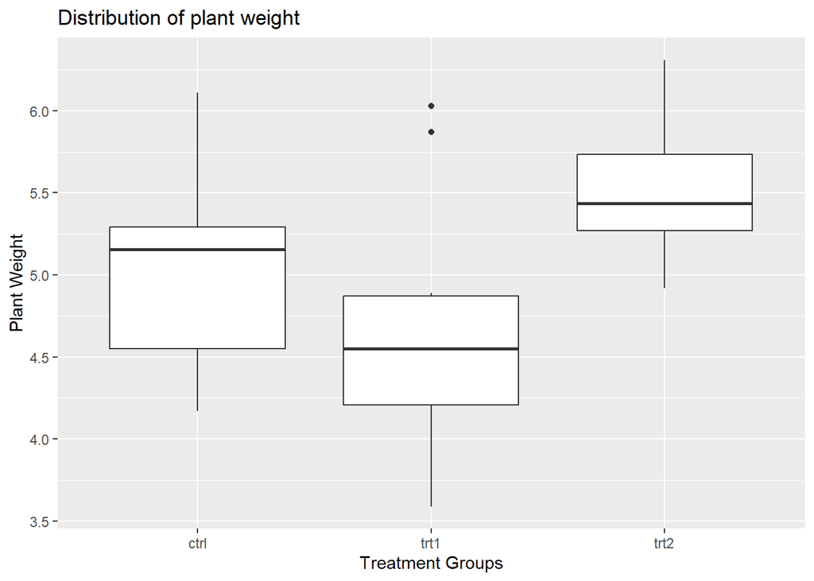

```r
ggplot(PlantGrowth, aes(x = group, y = weight))+
  geom_boxplot()+
  labs(title = "Distribution of plant weight ",
       x = "Treatment Groups",
       y = "Plant Weight")
```

Plants treated with Treatment2 has a higher mean weight compared to plants treated with Treatment1 and the Control group.

# Step 4: Run the ANOVA test

```r
summary(aov(PlantGrowth$weight~PlantGrowth$group))
```

```
##                   Df Sum Sq Mean Sq F value Pr(>F)
## PlantGrowth$group  2  3.766  1.8832   4.846 0.0159 *
## Residuals         27 10.492  0.3886
## ---
## Signif. codes:  0 '***' 0.001 '**' 0.01 '*' 0.05 '.' 0.1 ' ' 1
```

```r
qf(0.95, df1 = 2, df2 = 27)  # 0.95 = 1 - alpha
```

```
## [1] 3.354131
```

```r
qf(0.99, df1 = 2, df2 = 27)  # 0.95 = 1 - alpha
```

```
## [1] 5.488118
```

# Step 5: Interpretation of ANOVA test result

Suppose $\alpha = 0.01$ , fail to reject the null hypothesis as the p-value from the ANOVA test is 0.0159 The F (2,27) statistic, 4.846 < 5.488118. There isn’t sufficient evidence to conclude that the mean plant weights from the 3 treatment groups are different at 1% significance level.

Suppose $\alpha = 0.05$ then reject the null hypothesis as the p-value from the ANOVA test is 0.0159 is < 0.05 The F (2,27) statistic, 4.846 > 3.354131 There is evidence to conclude that the mean plant weights from the 3 treatment groups are different at 5% significance level.